# Activity 08: Hierarchical Clustering

### i. Single Linkage

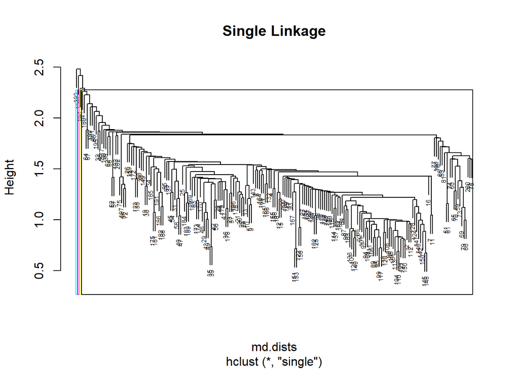

```r
plot(hc_single,
     main="Single Linkage",
     labels=md.names, cex=0.5)

# CMYK :)
rect.hclust(hc_single, k=4, border=c("cyan", "magenta", "yellow", "black"))
```

### ii. Ward’s Method

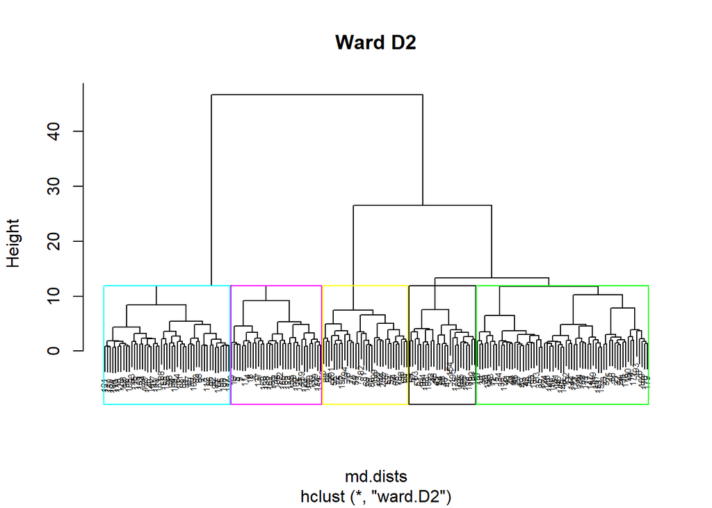

```r
plot(hc_ward,
     main="Ward D2",
     labels=md.names, cex=0.5)

# CMYK plus one other thing
rect.hclust(hc_ward, k=5, border=c("cyan", "magenta", "yellow", "black", "green"))
```

# B. K-means vs. Hierarchical

## 2. Are the clusters consistent?

If not, what do you think causes this, and how might it influence your interpretation of biological patterns in the data?

The clusters are not consistent. I think that this has to do with the algorithms we used. In Activity 07 we basically brute forced it and only checked up to k=10. For this activity we instead used functions that are (probably) more robust and statistically sound. The `hclust()` function must have been really well tested.

When it comes to interpreting biological patterns, even a difference of 1 in the number of clusters (k) like 3 vs. 4 is significant. Clusters that are grouped together when k=3 could be separate when k=4, for example. So things that you consider “related” in K-means could be considered not related in Hierachical Clustering. Another useful thing that HC provides is the ordering which you could use to determine the hierarchy, hence its name. It reminds me of a phlogenetic tree (like from Systematics) which is really useful to determine how related any one point is from the others.